# Tarea 4

Carlos Pires

15 de mayo de 2016

El presente markdown corresponde a la tarea 4 de la Materia MÃneria de datos. En el se describen todos todos los procesos que se realizaron al momento de atacar los problemas presentados por la tarea.

Se presentará una solución para cada uno de los problemas presentados en el documento Tarea_4.pdf

Haremos uso de las siguientes librerÃas:

```r
library(arulesViz)
library(arules)
```

A continuaciÃ³n, nos situaremos en el directorio de trabajo, cargaremos los datos, renombraremos ciertas columnas y cambiaremos algunos tipos de datos

```r
setwd("C:/Users/Carlos/Desktop/Universidad/Mineria/recomendacion-modelos-master")
dataset = read.csv('ejemplo.csv')
dataset_ejemplo = dataset
dataset = read.csv('periodico.csv')
colnames(dataset)[colnames(dataset) == 'articles'] = 'items'
dataset$articles = ''
dataset$items = as.character(dataset$items)
```

**1. Modificar su dataset de tal manera que no se lean los identificadores de los artículos como itemN sino por su tipo de contenido contenido/articuloN. Ejemplo: {item1, item10, item81} es la transacción {deportes/articulo1, politica/articulo1, opinion/articulo9}**

Para realizar esta demanda, se creo una función la cual se basa en expresiones regulares para obtener los números de los items de cada fila, luego se encargara de tomar la lista de números de cada arreglo de items y comenzará a iterar en la misma lista para conocer los números que componen cada item de las filas, luego de ese proceso, dependiendo del número, se concatenará una sección y un artículo.

NOTA IMPORTANTE: La manera en la que se desarrolló el algoritmo dió a conocer que es ineficiente en tiempo (tardando unos 15 minutos en realizar la tarea), sin embargo, el objetivo principal de realizar el proprocesamiento es cumplido.

```r
crear_articulos = function(databonder){
  for(iterator in databonder$X){
    temp2 = gregexpr("[0-9]+", databonder$items[iterator])
    numbers = as.numeric(unique(unlist(regmatches(databonder$items[iterator], temp2))))
    for (var in numbers){
      var_aux = var%%9
      if(var_aux == 0){
        var_aux = 9
      }
      if(var > 0 & var < 10){
        aux_deportes = 'deportes/articulo'
        result_deportes = paste(aux_deportes,var_aux, sep="")
        databonder$articles[iterator] = paste(databonder$articles[iterator],result_deportes, sep=",")
      }
      if(var > 9 & var < 19){
        aux_deportes = 'politica/articulo'
        result_deportes = paste(aux_deportes,var_aux, sep="")
        databonder$articles[iterator] = paste(databonder$articles[iterator],result_deportes, sep=",")
      }
      if(var > 18 & var < 28){
        aux_deportes = 'variedades/articulo'
        result_deportes = paste(aux_deportes,var_aux, sep="")
        databonder$articles[iterator] = paste(databonder$articles[iterator],result_deportes, sep=",")
      }
      if(var > 27 & var < 37){
        aux_deportes = 'internacional/articulo'
        result_deportes = paste(aux_deportes,var_aux, sep="")
        databonder$articles[iterator] = paste(databonder$articles[iterator],result_deportes, sep=",")
      }
      if(var > 36 & var < 46){
        aux_deportes = 'nacional/articulo'
        result_deportes = paste(aux_deportes,var_aux, sep="")
        databonder$articles[iterator] = paste(databonder$articles[iterator],result_deportes, sep=",")
      }
      if(var > 45 & var < 55){
        aux_deportes = 'sucesos/articulo'
        result_deportes = paste(aux_deportes,var_aux, sep="")
        databonder$articles[iterator] = paste(databonder$articles[iterator],result_deportes, sep=",")
      }
      if(var > 54 & var < 64){
        aux_deportes = 'comunidad/articulo'
        result_deportes = paste(aux_deportes,var_aux, sep="")
        databonder$articles[iterator] = paste(databonder$articles[iterator],result_deportes, sep=",")
      }
      if(var > 63 & var < 73){
        aux_deportes = 'negocios/articulo'
        result_deportes = paste(aux_deportes,var_aux, sep="")
        databonder$articles[iterator] = paste(databonder$articles[iterator],result_deportes, sep=",")
      }
      if(var > 72){
        aux_deportes = 'opinion/articulo'
        result_deportes = paste(aux_deportes,var_aux, sep="")
        databonder$articles[iterator] = paste(databonder$articles[iterator],result_deportes, sep=",")
      }
    }
  }
  return (databonder)
}
```

Una vez realizado este proceso para obtener la nueva columna ‘articles’, igualamos el dataset al nuevo ya preprocesado.

```r
z = crear_articulos(dataset)
dataset = z
```

Realizamos mÃ¡s preprocesamiento, elimnando las comas que aparecen delante de todos los articulos

```r
dataset$articles = substring(dataset$articles,2)
```

Y de esta manera culmina la parte de la pregunta nÃºmero 1 de la tarea.

En esta sección, haremos el análisis de detección de las conocidas transacciones bot, estas son descritas como transacciones que tienen menos de 20 segundos de actividad. Procedemos a encontrarlas.

Lo primero que observamos, es que tenemos la fecha de entreada y la fecha de salida de cada una de las transacciones, para poder encontrar el tiempo total de cuanto duro cada una de esta transacciones, la soluciÃ³n propuesta fue la siguiente:

Pasamos primero todos los tiempos a formato POSIX, puesto que de esta manera podemos manipular el tiempo como si fuera un entero, y de esta manera, restar la fecha de salida con la de entrada para poder obtener el tiemp total de la transacciÃ³n en segundos. Puesto que ya conocemos que POSIX es un formato de tiempo el cual cuenta los segundos transcurridos desde 1/1/1970.

```r
dataset$entry = as.numeric(as.POSIXct(dataset$entry, origin="1970-01-01"))
dataset$exit = as.numeric(as.POSIXct(dataset$exit, origin="1970-01-01"))
dataset$estadia = dataset$exit - dataset$entry
```

Luego que obtuvimos el tiempo de estadia, creamos un subset en el que tomaremos todas las estadias que sean mayores a 20 segundos y asi obtendermos el dataset limpio de transacciones bot.

```r
dataset = subset(dataset, estadia > 20)
```

Pare realizar las siguientes partes de la tarea, procedemos a procesar el dataset para crear una matriz de transacciones y de esa manera poder generar las reglas que utilizaremos en las siguientes actividades

Tomamos la columna de articulos y utilizamos los metodos para crear una matriz de transacciÃ³n

```r
arts = dataset$articles
write(arts, file = "transactions")
matriz_trans = read.transactions("transactions", format="basket", sep=",")
```

**2. Dado un usuario nuevo que haya ingresado a n artículos (n variable), poder recomendar un artículo n+1 y así aumentar el compromiso del cliente con su portal web. Como usted sabe, para poder calcular las reglas necesita como entrada MinSupport y MinConfianza. Sin embargo, el cliente desconoce cuáles son estos valores en consecuencia es tarea de usted determinar y justificar los mismos de acuerdo a su criterio.**

Para crear esta función, primero generamemos las reglas de asociación utilizando la librería arules, en especifico la función apriori. Para utilizar esta función, debemos establecer dos valores, un soporte y una confianza. El soporte (que es la proporción de veces que ocurrira la parte izquierda de la regla) será un valor bajo, puesto que queremos reglas que no sean comunes, y de igual manera, tendremos una confianza (la confianza será las veces que ocurra la parte izquierda de la regla dada que ocurrió la parte derecha) alta. Al hacer esta combinación de soporte y confianza, obtendremos un conjunto de reglas que no son muy frecuentes, pero, que en el momento que ocurran, podemos asegurar con un gran nivel de confianza que se cumplirá al pie de la letra.

Entonces, utilizando el mÃ©todo, generaremos las reglas:

```r
reglas_asoc = apriori(matriz_trans, parameter = list(support = 0.00002, confidence = 0.9))
```

```
## Apriori
##
## Parameter specification:
##  confidence minval smax arem  aval originalSupport support minlen maxlen
##         0.9    0.1    1 none FALSE            TRUE   2e-05      1     10
##  target   ext
##   rules FALSE
##
## Algorithmic control:
##  filter tree heap memopt load sort verbose
##     0.1 TRUE TRUE  FALSE TRUE    2    TRUE
##
## Absolute minimum support count: 2
##
## set item appearances ...[0 item(s)] done [0.00s].
## set transactions ...[81 item(s), 128998 transaction(s)] done [0.03s].
## sorting and recoding items ... [81 item(s)] done [0.00s].
## creating transaction tree ... done [0.07s].
## checking subsets of size 1 2 3 4 5 6 7 done [0.04s].
## writing ... [537 rule(s)] done [0.00s].
## creating S4 object  ... done [0.01s].
```

De igual manera hacemos un inspect, para constatar que se realizÃ³ correctamente.

```r
inspect(reglas_asoc)
```

```
##     lhs                          rhs                            support confidence       lift
## 1   {nacional/articulo8,
##      negocios/articulo1,
##      negocios/articulo6}      => {nacional/articulo6}      2.325617e-05        1.0  31.363482
## 2   {deportes/articulo6,
##      nacional/articulo7,
##      negocios/articulo1}      => {deportes/articulo3}      2.325617e-05        1.0   6.454418
## 3   {deportes/articulo4,
##      negocios/articulo1,
##      opinion/articulo3}       => {deportes/articulo1}      2.325617e-05        1.0   5.759868
## 4   {comunidad/articulo4,
##      comunidad/articulo8,
##      deportes/articulo2}      => {comunidad/articulo9}     3.100823e-05        1.0  31.234383
## 5   {comunidad/articulo4,
##      deportes/articulo4,
##      opinion/articulo9}       => {deportes/articulo2}      2.325617e-05        1.0   7.191727
## 6   {comunidad/articulo4,
##      deportes/articulo8,
##      politica/articulo5}      => {deportes/articulo2}      2.325617e-05        1.0   7.191727
## 7   {comunidad/articulo1,
##      deportes/articulo1,
##      variedades/articulo3}    => {deportes/articulo3}      2.325617e-05        1.0   6.454418
## 8   {comunidad/articulo1,
##      deportes/articulo5,
##      politica/articulo5}      => {deportes/articulo3}      2.325617e-05        1.0   6.454418
## 9   {nacional/articulo9,
##      negocios/articulo6,
##      sucesos/articulo4}       => {comunidad/articulo9}     2.325617e-05        1.0  31.234383
## 10  {comunidad/articulo9,
##      nacional/articulo9,
##      sucesos/articulo4}       => {negocios/articulo6}      2.325617e-05        1.0  39.042978
## 11  {deportes/articulo8,
##      internacional/articulo3,
##      sucesos/articulo4}       => {deportes/articulo4}      2.325617e-05        1.0   5.812554
## 12  {comunidad/articulo9,
##      deportes/articulo2,
##      sucesos/articulo1}       => {comunidad/articulo8}     2.325617e-05        1.0  57.614113
## 13  {deportes/articulo9,
##      negocios/articulo3,
##      negocios/articulo4}      => {deportes/articulo7}      2.325617e-05        1.0   5.858752
```

[output cut: 2109 more lines]

```
##      deportes/articulo5,
##      deportes/articulo6,
##      nacional/articulo1}      => {deportes/articulo2}      2.325617e-05        1.0   7.191727
## 536 {deportes/articulo2,
##      deportes/articulo4,
##      deportes/articulo5,
##      deportes/articulo6,
##      deportes/articulo7,
##      nacional/articulo1}      => {deportes/articulo1}      2.325617e-05        1.0   5.759868
## 537 {deportes/articulo1,
##      deportes/articulo2,
##      deportes/articulo4,
##      deportes/articulo6,
##      deportes/articulo7,
##      nacional/articulo1}      => {deportes/articulo5}      2.325617e-05        1.0   7.274460
```

A continuación, presentamos la función propuesta para recomendar un articulo, dada una transacción.

```r
recomendador = function(n_articulos,reglas){

  vector_art = unlist(strsplit(n_articulos, split=","))
  subset_reglas = subset(reglas, subset = lhs %ain% vector_art)
  final = inspect(unique(subset_reglas@rhs[1]))
  print ("Dado que usted leyo")
  print (vector_art)
  print ("PodrÃa interesarle")
  print (unique(final))
}
```

La función tomará un string de n articulos y los separá cada vez que encuentre un caracter ‘,’, generando un vector.

Lugo, aplicarÃ¡ un subset de reglas, donde el lado izquierdo sea el vector que acabamos de generar e imprimiremos el lado derecho.

Realizamos algunos ejemplos, donde podemos observar el funcionamiento de la funcion.

```r
recomendador("deportes/articulo1,politica/articulo3", reglas_asoc)
```

```
##   items
## 1 {deportes/articulo7}
## [1] "Dado que usted leyo"
## [1] "deportes/articulo1" "politica/articulo3"
## [1] "PodrÃa interesarle"
##                  items
## 1 {deportes/articulo7}
```

```r
recomendador("negocios/articulo6", reglas_asoc)
```

```
##   items
## 1 {nacional/articulo6}
## [1] "Dado que usted leyo"
## [1] "negocios/articulo6"
## [1] "PodrÃa interesarle"
##                  items
## 1 {nacional/articulo6}
```

```r
recomendador("deportes/articulo4,politica/articulo2", reglas_asoc)
```

```
##   items
## 1 {deportes/articulo9}
## [1] "Dado que usted leyo"
## [1] "deportes/articulo4" "politica/articulo2"
## [1] "PodrÃa interesarle"
##                  items
## 1 {deportes/articulo9}
```

```r
recomendador("deportes/articulo1,deportes/articulo2,deportes/articulo9", reglas_asoc)
```

```
##   items
## 1 {deportes/articulo4}
## [1] "Dado que usted leyo"
## [1] "deportes/articulo1" "deportes/articulo2" "deportes/articulo9"
## [1] "PodrÃa interesarle"
##                  items
## 1 {deportes/articulo4}
```

```r
recomendador("variedades/articulo9", reglas_asoc)
```

```
##   items
## 1 {opinion/articulo5}
## [1] "Dado que usted leyo"
## [1] "variedades/articulo9"
## [1] "PodrÃa interesarle"
##                 items
## 1 {opinion/articulo5}
```

**3. Conocer las 10 visitas con mayor tiempo de estadía en la página y las 10 visitas con menor tiempo de estadía en la página.**

Para conocer las 10 transacciones con menos estadia en la página bastará con hacer un sort del dataset e imprimri las 10 primeras transacciones

```r
menos = dataset
menos = menos[order(menos$estadia),]
head(menos, 10)
```

```
##           X         ID      entry       exit                       items
## 1000   1000  trans1000 1462143453 1462143474       {item8,item11,item59}
## 1172   1172  trans1172 1462102167 1462102188              {item1,item38}
## 2144   2144  trans2144 1462126876 1462126897                    {item11}
## 4698   4698  trans4698 1462191754 1462191775       {item7,item14,item24}
## 5216   5216  trans5216 1462248409 1462248430  {item5,item7,item8,item14}
## 5765   5765  trans5765 1462062542 1462062563       {item3,item18,item72}
## 6258   6258  trans6258 1462089456 1462089477        {item4,item7,item15}
## 11346 11346 trans11346 1461972951 1461972972               {item7,item9}
## 12413 12413 trans12413 1462067562 1462067583              {item9,item68}
## 13046 13046 trans13046 1462050201 1462050222 {item1,item4,item41,item69}
##                                                                          articles
## 1000                    deportes/articulo8,politica/articulo2,comunidad/articulo5
## 1172                                        deportes/articulo1,nacional/articulo2
## 2144                                                           politica/articulo2
```

[output cut: 18 more lines]

Y para conocer las 10 mayores, hacemos lo mismo procedimiento, ahora con el decreasing en TRUE.

```r
mas = dataset
mas = mas[order(mas$estadia, decreasing = TRUE),]
head(mas, 10)
```

```
##             X         ID      entry       exit
## 93676   93676 trans93676 1461955929 1461968193
## 7511     7511  trans7511 1462272617 1462284851
## 80516   80516 trans80516 1461965606 1461977349
## 122879 122879  trans4579 1462169529 1462181126
## 130641 130641  trans7341 1462076846 1462088354
## 66995   66995 trans66995 1462238091 1462249572
## 111953 111953  trans1653 1462134198 1462145619
## 23099   23099 trans23099 1462186559 1462197978
## 55628   55628 trans55628 1462001832 1462013213
## 48007   48007 trans48007 1461993967 1462005339
##                                          items
## 93676                          {item16,item70}
## 7511                           {item14,item63}
## 80516                   {item14,item37,item45}
```

[output cut: 29 more lines]

**4. Conocer las 10 transacciones con mayor número de apariciones en el dataset.** Para conocer estas transacciones, lo que realizaremos, será crear una nueva matriz de transacciones, en la que tendremos sólo el identificador de la transacción y el artículo.

```r
trans_art = dataset
trans_art = split(trans_art$articles,trans_art$X)
trans_art = as(trans_art,"transactions")
```

Luego, en esta nueva matriz, tenemos identificadores y transacciones, a partir de alli, vemos los primeros 10 conjuntos de articulos

```r
head(sort(itemFrequency(trans_art), decreasing = TRUE), 10)
```

```
## deportes/articulo1 deportes/articulo4 deportes/articulo7
##        0.008139661        0.008100901        0.008085397
## deportes/articulo3 deportes/articulo9 deportes/articulo6
##        0.007162902        0.007007861        0.006930340
## deportes/articulo8 deportes/articulo5 deportes/articulo2
##        0.006728786        0.006589249        0.006418704
## politica/articulo5
##        0.003410906
```

**Función Generadora de Curva ROC**

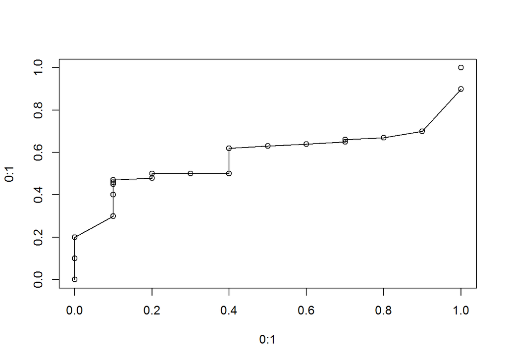

```r
generate_ROC = function(scores, real, target ){
  dimen = 0
  x = x1 = 0
  y = y1 = 0
  plot(0:1,0:1)
  for (i in 1:length(scores)){
    if(real[i] == target){
      y = dimen
      y1 = 1-scores[i]
      points(dimen, 1-scores[i])
      lines(c(x,y),c(x1,y1))
      x = dimen
      x1 = 1-scores[i]
    }else{
      dimen = dimen+ 0.1
      y = dimen
      y1 = 1-scores[i]
      points(dimen, 1-scores[i])
      lines(c(x,y),c(x1,y1))
      x = dimen
      x1 = 1-scores[i]

    }

  }

}

generate_ROC(c(0.9, 0.8, 0.7, 0.6, 0.55, 0.54, 0.53, 0.52, 0.5, 0.5, 0.5, 0.5, 0.38, 0.37, 0.36, 0.35, 0.34, 0.33, 0.30, 0.1),c(2, 2, 1, 2, 2, 2, 2, 1, 2, 1, 2, 1, 2, 1, 1, 1, 2, 1, 1, 1), 2)
```